# Project_V1

Vimaljeet Singh

2023-04-18

```r
source("C:/Users/vjsng/Data589/Spatial-Analysis-Honey-Bees/data_processing.R")
```

[figure not shown]

```r
plot(apis_data_ppp)
```

[figure not shown]

## Number of data points

```r
# number of points

npoints(apis_data_ppp)
```

```
## [1] 2610
```

## Intensity

Assuming intensity is homogeneous, we use the inbuilt function to find the value of intensity.

```r
# intensity

intensity(apis_data_ppp)
```

```
## [1] 2.752403e-09
```

## Quadrat counting

In most real scenarios, $\lambda$ is likely to be spatially varying. When $\lambda$ is spatially varying, the intensity at any location u is $\lambda(u)$ and it can be estimated non-parametrically by dividing the window into sub-regions called quadrats.

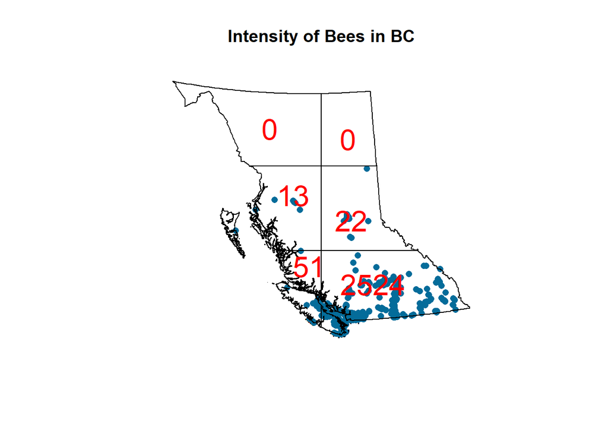

```r
# quadrat counting (4x2 quadrat)

myquadrat = quadratcount(apis_data_ppp, nx = 2, ny = 3)
plot(apis_data_ppp, pch = 16, use.marks=F, cols = "#046C9A", main = "Intensity of Bees in BC")
plot(myquadrat, cex=2, col="red", add=T)
```

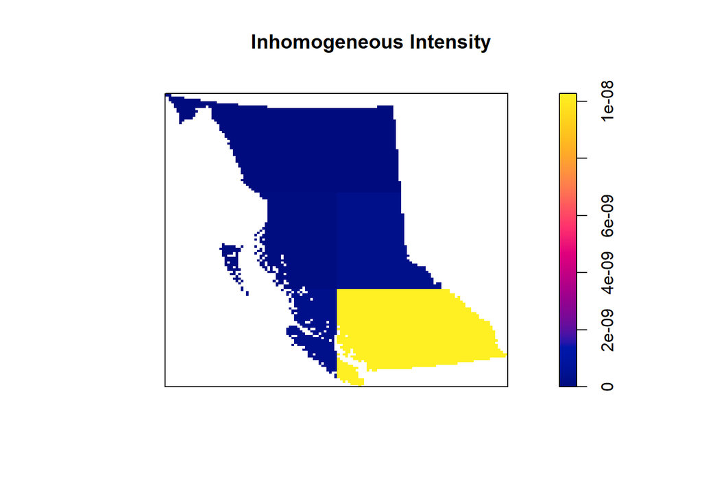

```r
# plot intensity in each quadrat
plot(intensity(myquadrat, image=T), main = "Inhomogeneous Intensity")
```

Clearly, the assumption of homogeneity is inappropriate for this dataset as the bees tend to be clustered in certain areas of the study site, whereas others have no bees at all. Quadrat counting suggests a spatially varying, inhomogeneous $\lambda(u)$ , but point processes are stochastic and some variation is expected by chance alone. Our eyes are also a poor judge of homogeneity, so we should ideally test for spatial (in)homogeneity objectively. Under a null hypothesis that the intensity is homogeneous, we carry out the test for significant deviations from complete spatial randomness.

## Test of homogeneity

```r
# test of homogeneity

quadrat.test(myquadrat)
```

```
##
##  Chi-squared test of CSR using quadrat counts
##
## data:
## X2 = 6815.8, df = 5, p-value < 2.2e-16
## alternative hypothesis: two.sided
##
## Quadrats: 6 tiles (irregular windows)
```

The small p-value (< 2.2e-16) indicates that the observed pattern of points is significantly non-random with very strong evidence against the null hypothesis of complete spatial randomness (CSR) at any significance level. Hence, there is a significant deviation from homogeneity. The p-value doesn’t provide any information on the cause of inhomogeneity, however, and significant deviations can be due to the processes truly being inhomogeneous, but also due to a lack of independence between points.

## Kernel Estimation

A spatially varying, λ(u) can also be estimated non-parametrically by kernel estimation.

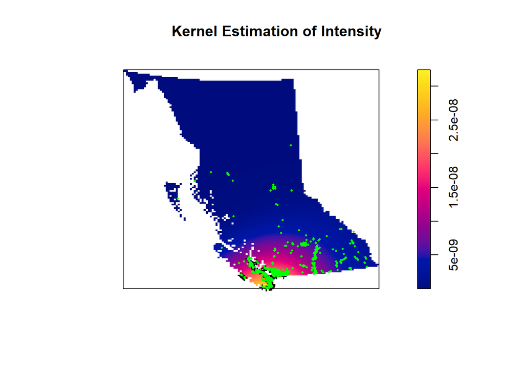

```r
# kernel estimation

lambda_u_hat = density(apis_data_ppp)
plot(lambda_u_hat, main="Kernel Estimation of Intensity")
plot(apis_data_ppp, pch=16, cex=0.4, add=T, use.marks=F, cols="green")
```

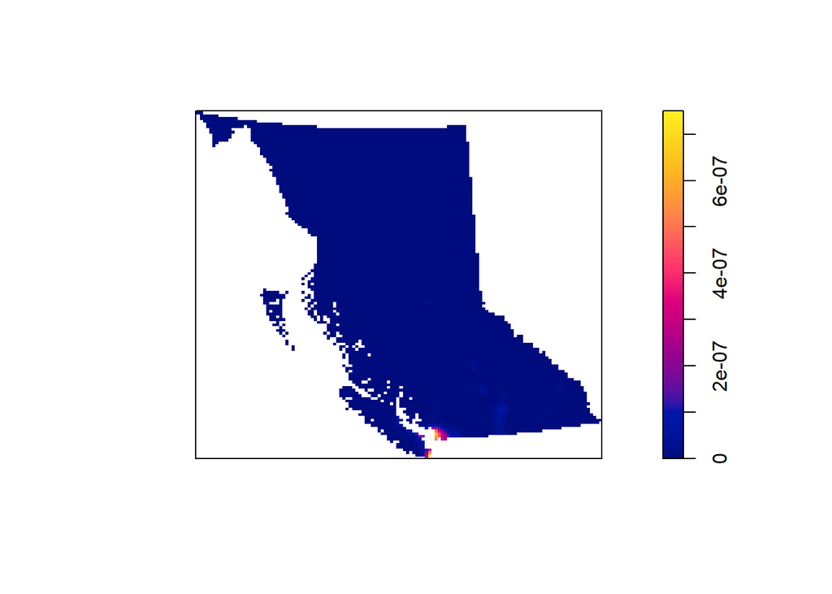

```r
# using different bandwidth optimiser

plot(density(apis_data_ppp, sigma = bw.ppl),  # Likelihood Cross Validation Bandwidth Selection
     ribbon = T,
     main = "")
```

Using the plots above, we can see that south BC has high intensity and there is mostly no change in the northern and central BC area. This is consistent with the findings of the quadrat count graph as well.

## Hot spot analysis

Even though we can see from the plot above that the intensity is inhomogeneous and higher in the south, we would still like to identify areas where the intensity is elevated. This is what we will do below using scan test.

As the intensity is inhomogeneous, at each location u, we can draw a circle of radius r (we call this my_R in the code below) and then count the number of points in and out of the circle. This r has been found through kernel bandwidth optimization. Also, under an assumption that the process is Poisson distributed, we can calculate a likelihood ratio test statistics for the number of points inside vs. outside of the circle. The null distribution is $\chi^2$ with 1 degree of freedom allowing us to calculate p-values at each location u.

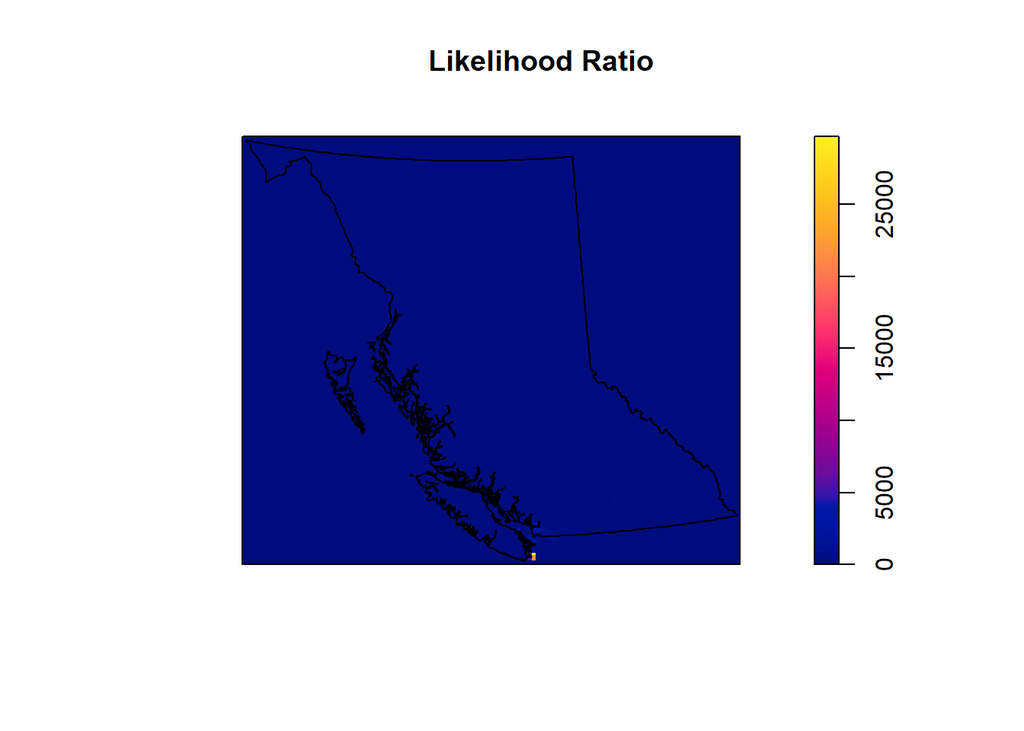

```r
# hotspot analysis via scan test

# estimate R
my_R = bw.ppl(apis_data_ppp)

# calculate test statistic
my_lr = scanLRTS(apis_data_ppp, r= my_R)

# plot the output
plot(my_lr, main="Likelihood Ratio")
plot(BC_win, add=T)
```

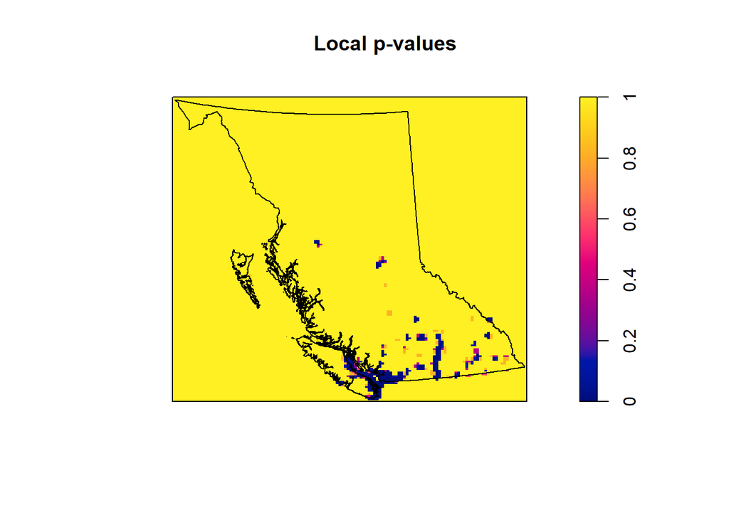

```r
# compute pvalues
pvals = eval.im(pchisq(my_lr, df=1, lower.tail=F))

# plot output
plot(pvals, main = "Local p-values")
plot(BC_win, add=T)
```

From the p-value plot, we can see that the hot spot areas are more densely situated towards the south of BC.

```r
# estimate rho
#
# rho = rhohat(apis_data_ppp, elevation)
# plot(rho, main="Rho vs Elevation")
```

## Using Ripley’s $K$-function to test for a significant (i.e., $\alpha$ = 0.05) correlation between locations

```r
#Estimate a strictly positive density
lambda <- density(apis_data_ppp, sigma=bw.ppl, positive=TRUE)

inhom <- envelope(apis_data_ppp,
                  Kinhom,
                  simulate = expression(rpoispp(lambda)),
                  correction="border",
                  rank = 1,
                  nsim = 19, # for alpha = 0.05
                  fix.n = TRUE)
```

```
## Generating 19 simulations by evaluating expression  ...
## 1, 2, 3, 4, 5, 6, 7, 8, 9, 10, 11, 12, 13, 14, 15, 16, 17, 18,  19.
##
## Done.
```

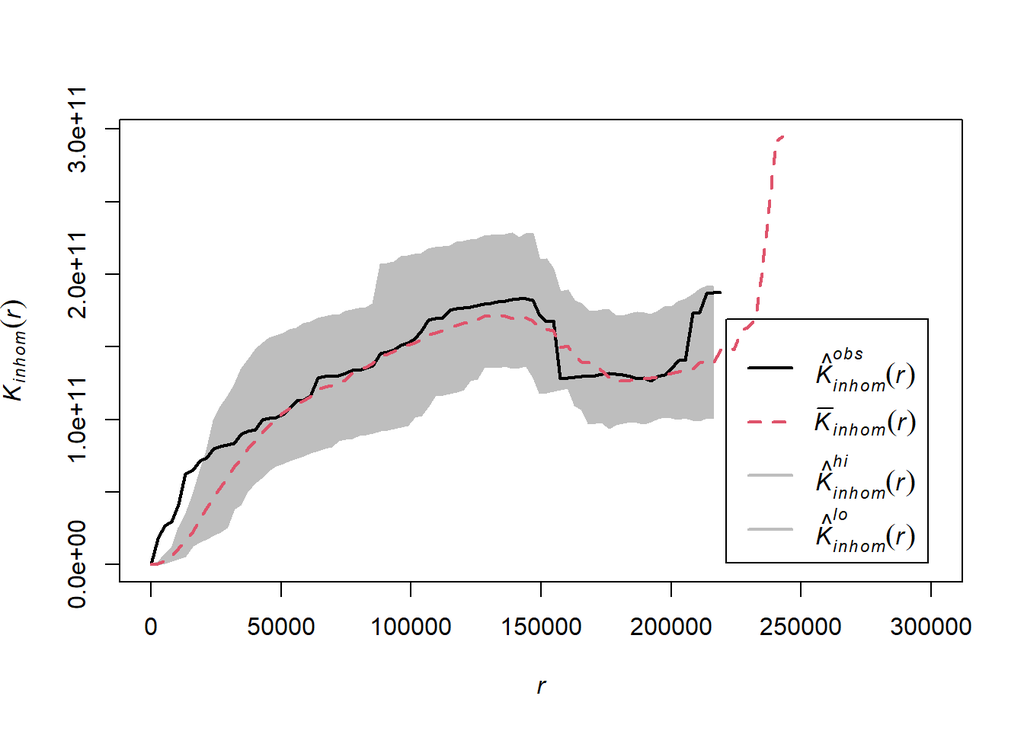

```r
# visualise the results
# par(mfrow=c(1,2))
plot(inhom, main = "", lwd = 2, xlim=c(0, 300000))
```

## Estimating both the homogeneous and inhomogeneous pair correlation functions, using simulation envelopes.

```r
## Simulation envelope (with points drawn from the estimated intensity)

# homogeneous
pcf_hom <- envelope(apis_data_ppp,
                    pcf,
                    simulate = expression(rpoispp(lambda)),
                    rank = 1,
                    nsim = 19)
```

```
## Generating 19 simulations by evaluating expression  ...
## 1, 2, 3, 4, 5, 6, 7, 8, 9, 10, 11, 12, 13, 14, 15, 16, 17, 18,  19.
##
## Done.
```

```r
# inhomogeneous
pcf_inhom <- envelope(apis_data_ppp,
                      pcfinhom,
                      simulate = expression(rpoispp(lambda)),
                      rank = 1,
                      nsim = 19)
```

```
## Generating 19 simulations by evaluating expression  ...
## 1, 2, 3, 4, 5, 6, 7, 8, 9, 10, 11, 12, 13, 14, 15, 16, 17, 18,  19.
##
## Done.
```

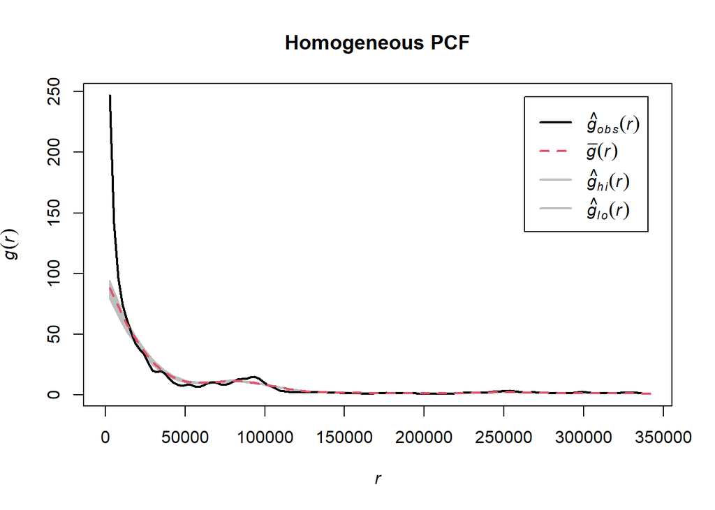

```r
# visualise the results
plot(pcf_hom, main="Homogeneous PCF", lwd=2)
```

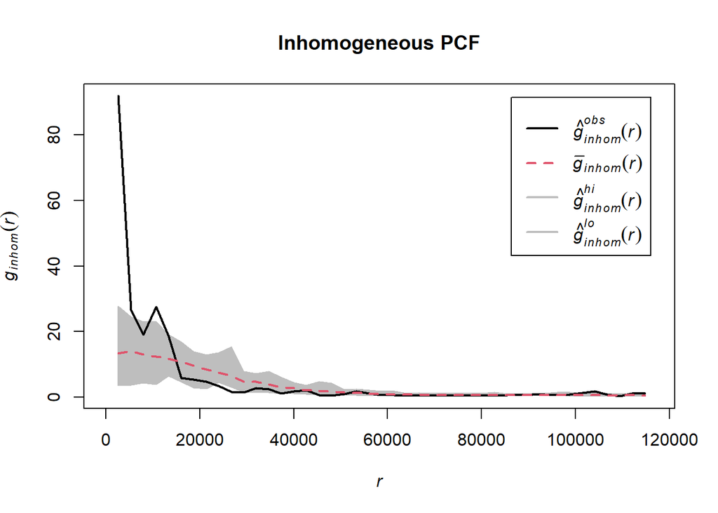

```r
plot(pcf_inhom, main="Inhomogeneous PCF", lwd=2)
```

g(r) is the probability of observing a pair of points of the process separated by a distance r, divided by the corresponding probability for a Poisson process. Pair correlations function contains contributions only from inter-point distances equal to r (and not <= r). We will use the inhomogeneous pair correlation function as our point process is inhomogeneous. As g(r)> 1 indicates that this inter-point distance is more frequent than expected for a completely random pattern, which suggests clustering, we can say that there is significant evidence of clustering at lower values of r for our point process.